# Introduction to Machine Learning - Term Project

### Nilay Kamar

Nowadays, social media has been a tool in which people can say their opinions about everything. These posts can be generally related to actual news, their likes, thoughts, suggestions, hate, etc. If these posts can be analyzed, companies would get insights from them to use in their campaigns or customer segmentation studies.

Both touching the social point and developing myself on text mining, I chose to analyze tweets contain given hashtags. We have witnessed many upsetting things as a Turkish in the last decade. My purpose of the term project is to analyze the sentiment of these tweets and extract some insights from them.

Because of the lack of turkish text mining studies corresponding to english, there are a huge challenging work area to study on term project. I have been used well known libraries to see how the model can be developed.

## Importing libraries

```python
from warnings import filterwarnings
filterwarnings('ignore')
import pandas as pd
import datetime
import csv
import numpy as np
import datetime
import glob
import tweepy, codecs
import time
%matplotlib inline
from sklearn.utils import shuffle
import matplotlib.pyplot as plt
import seaborn as sns
import matplotlib.gridspec as gridspec
#color = sns.color_palette()
from wordcloud import WordCloud ,STOPWORDS
from PIL import Image
import re
from nltk.tokenize import TweetTokenizer
from nltk.stem.wordnet import WordNetLemmatizer
color = sns.color_palette()
import textblob
import nltk
from nltk.corpus import stopwords
from sklearn.feature_extraction.text import TfidfVectorizer, CountVectorizer
#import locale;
#print(locale.getdefaultlocale());
from IPython.display import Image
from IPython.core.display import HTML
from sklearn.metrics import accuracy_score
from sklearn.metrics import recall_score
from sklearn.metrics import precision_score
from sklearn.metrics import confusion_matrix
from sklearn.linear_model import LogisticRegression
from sklearn.ensemble import AdaBoostClassifier
from sklearn.model_selection import cross_val_score
from sklearn.naive_bayes import MultinomialNB
from scipy.sparse import hstack
import pipeline_caller as pc
```

## About the data

Because of the restrictions of the Twitter API to get tweets posted in older than seven days, I used to library shows on Github repository to get all tweets posted on since 01.01.2010 until 01.05.2020. To get user information of these tweets, I benefited from Twitter API. the library which I used in getting tweets, searching tweets with given filters, reading HTML pages, and writing them on CSV files. I got tweets with filters contains different hashtags, and save them on a given folder.

Firstly, I combined all CSV files in the given folder, and store them data frame object.

```python
df = pd.DataFrame()
for f in glob.glob("/Users/nilaykamar/PycharmProjects/ML_project/RawData/*.csv"):
    temp_df = pd.read_csv(f, sep = "\t")
    df = df.append(temp_df,ignore_index=True)
```

Firstly, it should be done preprocessing on the dataset. Preprocessing is the hardest part of a machine learning project, however, text mining is also challenging because of being unstructured. Converting turkish characters, extracting additional features, conversion of timestamp to date format can be counted as parts of preprocessing. Removing urls, picture links, and mentions is an essential for tweets datasets.

```python
def preprocessing(df):
    #drop duplicates
    df = df.drop_duplicates(subset=None, keep='first', inplace=False)
    df = df.drop_duplicates(subset= "text", keep='first', inplace=False)
    #convert turkish characters
    conversionTable = str.maketrans("ğĞıİöÖüÜşŞçÇ", "gGiIoOuUsScC")
    df["text"] = df["text"].apply(lambda x: x.translate(conversionTable))
    df['text'] = df['text'].apply(lambda x: " ".join(x.lower() for x in x.split()))
    #extract date, hour, and day features of tweets
    df["date"] = df["date"].apply(lambda x: datetime.datetime.strptime(x, '%Y-%m-%d %H:%M'))
    df["tweet_hour"] = pd.to_numeric(df["date"].apply(lambda x: x.strftime("%H")))
    df["day"] = df["date"].apply(lambda x: x.strftime("%A"))
    #extract hashtags and create a new column
    df["hashtag"] = df['text'].apply(lambda x: re.findall(r'\B#\w*[0-9A-Za-z]+\w*', x))
    df["text_modified"] = df['text'].apply(lambda x: re.sub(r'\B#\w*[0-9A-Za-z]+\w*', '', x)) #modified tweets
    #extract pictures and create a new column
    df["pictures"] = df['text'].apply(lambda x: re.findall('\S*twitter.com\S*', x))
    df["text_modified"] = df['text_modified'].apply(lambda x: re.sub('\S*twitter.com\S*', '', x)) #modified tweets
    #extract url and create a new column
    df["url"] = df['text'].apply(lambda x: re.findall(r'https?:\/\/.*[\r\n]*', x))
    df["text_modified"] = df['text_modified'].apply(lambda x: re.sub(r'https?:\/\/.*[\r\n]*', '', x)) #modified tweets
    #extract mentions and create a new column
    df["mentions"] = df['text'].apply(lambda x: re.findall(r"(?:\@|https?\://)\S+", x))
    df["text_modified"] = df['text_modified'].apply(lambda x: re.sub(r"(?:\@|https?\://)\S+", '', x, flags=re.MULTILINE)) #modified tweets
    #extratc punctuations
    df["text_modified"] = df['text_modified'].apply(lambda x: re.sub('[^\w\s]', '', x)) #modified tweets
    #removing numbers
    df["text_modified"] = df['text_modified'].apply(lambda x: re.sub('\d', '', x)) #modified tweets
    #removing redundant spaces
    df["text_modified"] = df["text_modified"].apply(lambda x: x.strip().replace("  ", " "))
    df["text_modified"] = df["text_modified"].apply(lambda x: x.strip().replace("   ", ""))
    return df
```

```python
df = preprocessing(df)
```

```python
df.id = pd.Categorical(df.id)
```

```python
df.describe().T
```

|  | count | mean | std | min | 25% | 50% | 75% | max |
| --- | --- | --- | --- | --- | --- | --- | --- | --- |
| retweets | 100681.0 | 2.579732 | 23.728643 | 0.0 | 0.0 | 0.0 | 1.0 | 3003.0 |
| favorites | 100681.0 | 6.094437 | 54.595811 | 0.0 | 0.0 | 0.0 | 2.0 | 8631.0 |
| geo | 0.0 | NaN | NaN | NaN | NaN | NaN | NaN | NaN |
| tweet_hour | 100681.0 | 12.257914 | 8.648352 | 0.0 | 2.0 | 13.0 | 21.0 | 23.0 |

```python
df.head()
```

|  | username | date | retweets | favorites | text | geo | mentions | hashtags | id | permalink | tweet_hour | day | hashtag | text_modified | pictures | url |
| --- | --- | --- | --- | --- | --- | --- | --- | --- | --- | --- | --- | --- | --- | --- | --- | --- |
| 0 | avukatyoraz | 2015-12-31 09:09:00 | 1 | 0 | #yilinsongunundeben unutma!.. @candundaradasi ... | NaN | [@candundaradasi, @erdemgul] | #yilinsong #unutma #unutturma | 682458513671585792 | https://twitter.com/avukatyoraz/status/6824585... | 9 | Thursday | [#yilinsongunundeben, #unutma, #unutturma] | unutma ve sadece gazetecilik yaptiklari icin ... | [] | [] |
| 1 | BrandMAPTR | 2015-12-30 23:19:00 | 0 | 0 | #2016 #2015 #gelecek #unutma #unutturma pic.tw... | NaN | [] | #2016 #2015 #gelecek #unutma #unutturma | 682310005501071360 | https://twitter.com/BrandMAPTR/status/68231000... | 23 | Wednesday | [#2016, #2015, #gelecek, #unutma, #unutturma] |  | [pic.twitter.com/h8e0p8bay9] | [] |
| 2 | BrandMAPTR | 2015-12-30 23:18:00 | 0 | 1 | #2016 #2015 #gelecek #unutma #unutturma pic.tw... | NaN | [] | #2016 #2015 #gelecek #unutma #unutturma | 682309785358852096 | https://twitter.com/BrandMAPTR/status/68230978... | 23 | Wednesday | [#2016, #2015, #gelecek, #unutma, #unutturma] |  | [pic.twitter.com/ujq2cjbiuq] | [] |
| 3 | Terliksi_Kerim | 2015-12-30 23:02:00 | 0 | 1 | 11 subat 2015 rizespor fenerbahce macinda futb... | NaN | [] | #unutma #unutturma | 682305706121400320 | https://twitter.com/Terliksi_Kerim/status/6823... | 23 | Wednesday | [#unutma, #unutturma] | subat rizespor fenerbahce macinda futbol katli... | [] | [] |
| 4 | BrandMAPTR | 2015-12-30 13:51:00 | 3 | 3 | #2016 #2015 #gelecek #unutma #unutturma pic.tw... | NaN | [] | #2016 #2015 #gelecek #unutma #unutturma | 682167170202267648 | https://twitter.com/BrandMAPTR/status/68216717... | 13 | Wednesday | [#2016, #2015, #gelecek, #unutma, #unutturma] |  | [pic.twitter.com/sddjanrlg7] | [] |

```python
df.info()
```

```
<class 'pandas.core.frame.DataFrame'>
Int64Index: 100681 entries, 0 to 158242
Data columns (total 16 columns):
 #   Column         Non-Null Count   Dtype
---  ------         --------------   -----
 0   username       100681 non-null  object
 1   date           100681 non-null  datetime64[ns]
 2   retweets       100681 non-null  int64
 3   favorites      100681 non-null  int64
 4   text           100681 non-null  object
 5   geo            0 non-null       float64
 6   mentions       100681 non-null  object
 7   hashtags       100681 non-null  object
 8   id             100681 non-null  category
 9   permalink      100681 non-null  object
 10  tweet_hour     100681 non-null  int64
 11  day            100681 non-null  object
 12  hashtag        100681 non-null  object
 13  text_modified  100681 non-null  object
 14  pictures       100681 non-null  object
 15  url            100681 non-null  object
dtypes: category(1), datetime64[ns](1), float64(1), int64(3), object(10)
memory usage: 15.9+ MB
```

```python
df.day = pd.Categorical(df.day)
```

## Explonatary Data Analysis

It should be applied explanatory data analysis on the dataset to get more clear data before modelling. Tweet dataset is about text, it must be some conversions and remove unnecessary features.

### Which time and day people mostly post a tweet?

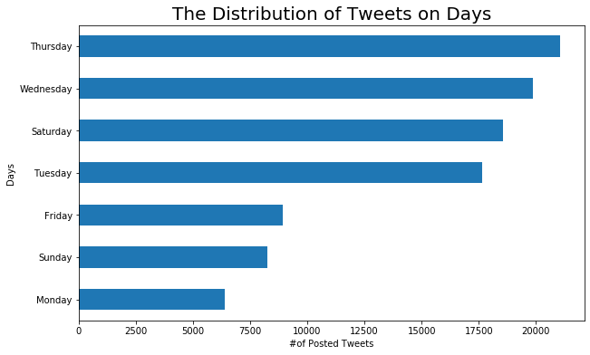

```python
df.groupby("day").count()["id"].sort_values().plot(x = "day", y = "id", kind = "barh", figsize=(10,6))
plt.title("The Distribution of Tweets on Days", fontsize = 20)
plt.ylabel("Days")
plt.xlabel("#of Posted Tweets");
```

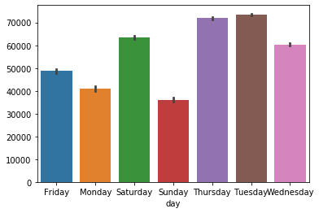

```python
sns.barplot(x = "day", y = df.day.index, data = df);
```

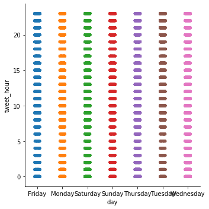

```python
sns.catplot(x = "day", y = "tweet_hour", data = df);
```

People have mostly been seem to post tweets on Thurdays.

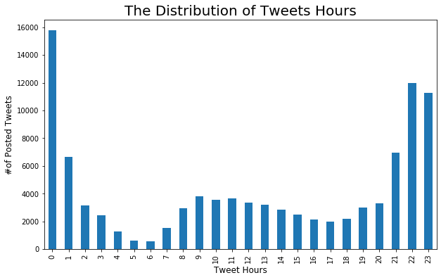

```python
df.groupby("tweet_hour").count()["id"].plot(x = "tweet_hours", y = "id", kind = "bar", figsize = (10,6))
plt.title("The Distribution of Tweets Hours", fontsize = 20)
plt.xlabel("Tweet Hours", fontsize = 12)
plt.ylabel("#of Posted Tweets", fontsize = 12)
```

Evening hours are so popular to post a tweet!

```python
time_df = df.loc[:,["id", "text", "date"]]
time_df["year"] = time_df["date"].apply(lambda x: x.strftime("%Y"))
time_df["month"] = time_df["date"].apply(lambda x: x.strftime("%m"))
time_df["day"] = time_df["date"].apply(lambda x: x.strftime("%d"))
```

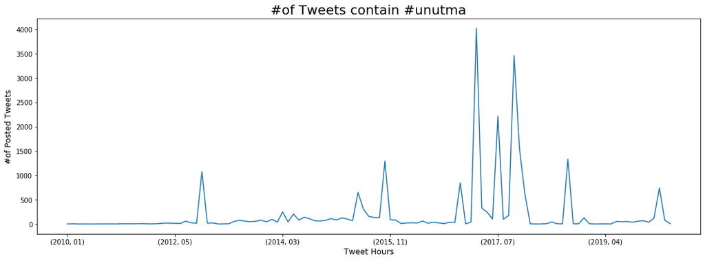

```python
time_df[time_df['text'].str.match('#unutma')].groupby(["year", "month"]).size().plot(x = "tweet_hours", y = "id", kind = "line", figsize = (18,6))
plt.title("#of Tweets contain #unutma", fontsize = 20)
plt.xlabel("Tweet Hours", fontsize = 12)
plt.ylabel("#of Posted Tweets", fontsize = 12)
```

Tweets contain hashtag of "unutma" have higher on july at 2017. The number of tweets line have some jumps as shown graph above.

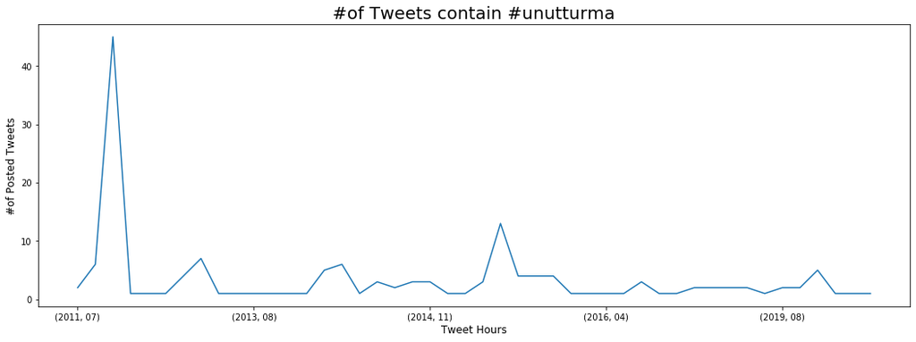

```python
time_df[time_df['text'].str.match('#unutturma')].groupby(["year", "month"]).size().plot(x = "tweet_hours", y = "id", \
                                                                                        kind = "line", figsize = (18,6))
plt.title("#of Tweets contain #unutturma", fontsize = 20)
plt.xlabel("Tweet Hours", fontsize = 12)
plt.ylabel("#of Posted Tweets", fontsize = 12)
```

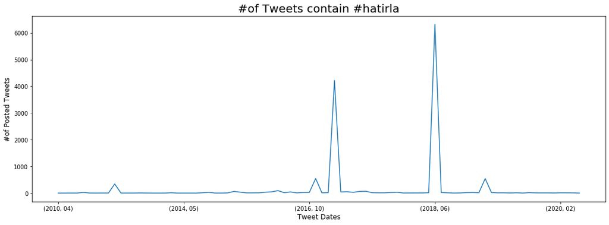

```python
time_df[time_df['text'].str.match('#hatirla')].groupby(["year", "month"]).size().plot(x = "tweet_hours", y = "id", \
                                                                                        kind = "line", figsize = (18,6))
plt.title("#of Tweets contain #hatirla", fontsize = 20)
plt.xlabel("Tweet Dates", fontsize = 12)
plt.ylabel("#of Posted Tweets", fontsize = 12)
```

```python
def count(df):
    lst = df["id"]
    df["text_len"] = [len(df.loc[df["id"] == i]["text_modified"].to_string().replace("  ", " ")) for i in lst]
    df["word_count"] = [len(str(df.loc[df["id"] == i]["text_modified"].to_string().replace("  ", " ")).split(" ")) for i in lst]
    return df
df = count(df)
```

```python
#Lets see other useful information that can be gathered:
#MEAN LENGTH OF THE TWEETS
print("The mean length of the tweets is:", np.mean(df['text_len']))
#TWEETS WITH AN URL
url_tweets = df[df['text'].str.contains("http")]
print(f"The percentage of tweets with Urls is {round(len(url_tweets)/len(df)*100)}% of all the tweets")
#MEAN TWEETS PER USER
print("Number of tweets per user:", len(df)/df['username'].nunique())
```

```
The mean length of the tweets is: 40.544194038597155
The percentage of tweets with Urls is 17% of all the tweets
Number of tweets per user: 2.003362782553327
```

```python
df.isna().sum()
```

```
username              0
date                  0
retweets              0
favorites             0
text                  0
geo              100681
mentions              0
hashtags              0
id                    0
permalink             0
tweet_hour            0
day                   0
hashtag               0
text_modified         0
pictures              0
url                   0
text_len              0
word_count            0
dtype: int64
```

The column of geo have na values, therefore it must be removed. It is generally preferred removing columns have less importance such as URLs or permalink in the dataset. So, it is formed new dataframe includes columns only to be used.

```python
df_final = df[df["word_count"]!=3].reset_index()
df_final = df_final.loc[:,["id", "text_modified", "hashtag", "mentions", "pictures", "url", \
                           "username", "retweets", "favorites", "date", "day", "tweet_hour", "text_len", "word_count"]]
```

```python
df_final.head()
```

|  | id | text_modified | hashtag | mentions | pictures | url | username | retweets | favorites | date | day | tweet_hour | text_len | word_count |
| --- | --- | --- | --- | --- | --- | --- | --- | --- | --- | --- | --- | --- | --- | --- |
| 0 | 682458513671585792 | unutma ve sadece gazetecilik yaptiklari icin ... | [#yilinsongunundeben, #unutma, #unutturma] | [@candundaradasi, @erdemgul] | [] | [] | avukatyoraz | 1 | 0 | 2015-12-31 09:09:00 | Thursday | 9 | 51 | 9 |
| 1 | 682305706121400320 | subat rizespor fenerbahce macinda futbol katli... | [#unutma, #unutturma] | [] | [] | [] | Terliksi_Kerim | 0 | 1 | 2015-12-30 23:02:00 | Wednesday | 23 | 52 | 8 |
| 2 | 681880697762660353 | unutursak kalbimiz kurusun | [#unutma, #unutturma, #hilal, #dogus] | [@hazalguvenc] | [] | [] | Fernwehhli | 0 | 0 | 2015-12-29 18:53:00 | Tuesday | 18 | 29 | 5 |
| 3 | 681673537996861444 | adaletin batsin dunya | [#soylemedenedemicem, #cocukbedenimedokunma, #... | [] | [] | [] | BuGuMm | 0 | 1 | 2015-12-29 05:10:00 | Tuesday | 5 | 24 | 5 |
| 4 | 681562788372852737 | ataturkun adini agzina alip dis guclerin oyunc... | [#unutma, #unutturma] | [] | [] | [http:// fb.me/4mccl3hie] | namluyurek | 0 | 0 | 2015-12-28 21:50:00 | Monday | 21 | 53 | 9 |

### How long tweets are posted?

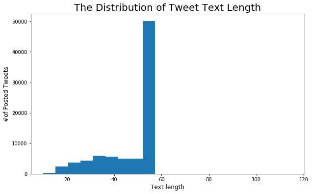

```python
df_final['text_len'].plot(kind='hist', bins=20, figsize=(10,6))
plt.title("The Distribution of Tweet Text Length", fontsize = 20)
plt.xlabel("Text length", fontsize = 12)
plt.ylabel("#of Posted Tweets", fontsize = 12)
```

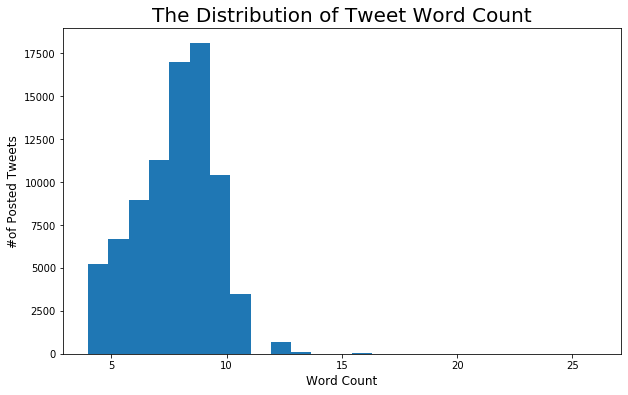

```python
df_final['word_count'].plot(kind='hist', bins=25, figsize=(10,6))
plt.title("The Distribution of Tweet Word Count", fontsize = 20)
plt.xlabel("Word Count", fontsize = 12)
plt.ylabel("#of Posted Tweets", fontsize = 12)
```

People seems to prefer posting tweets approximately by 10 words contain 60 characters.

### How about retweets and favorites of tweets?

[figure not shown]

```python
df.plot(kind='scatter', x='retweets', y='favorites', figsize=(10,6))
plt.title("The Relationship between Retweets and Favourites", fontsize = 20)
plt.xlabel("Tweet Favorites", fontsize = 12)
plt.ylabel("Tweet Retweets", fontsize = 12)
```

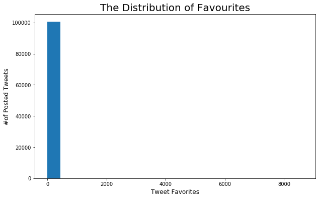

```python
df['favorites'].plot(kind='hist', bins=20, figsize=(10,6))
plt.title("The Distribution of Favourites", fontsize = 20)
plt.xlabel("Tweet Favorites", fontsize = 12)
plt.ylabel("#of Posted Tweets", fontsize = 12)
```

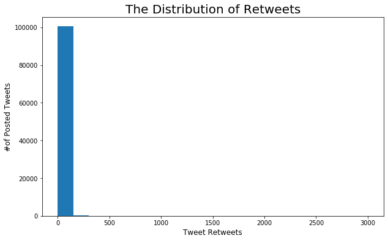

```python
df['retweets'].plot(kind='hist', bins=20, figsize=(10,6))
plt.title("The Distribution of Retweets", fontsize = 20)
plt.xlabel("Tweet Retweets", fontsize = 12)
plt.ylabel("#of Posted Tweets", fontsize = 12)
```

The majority of tweets have 0 favorites and 0 retweets. It's interesting!

### Is there any corelation between features?

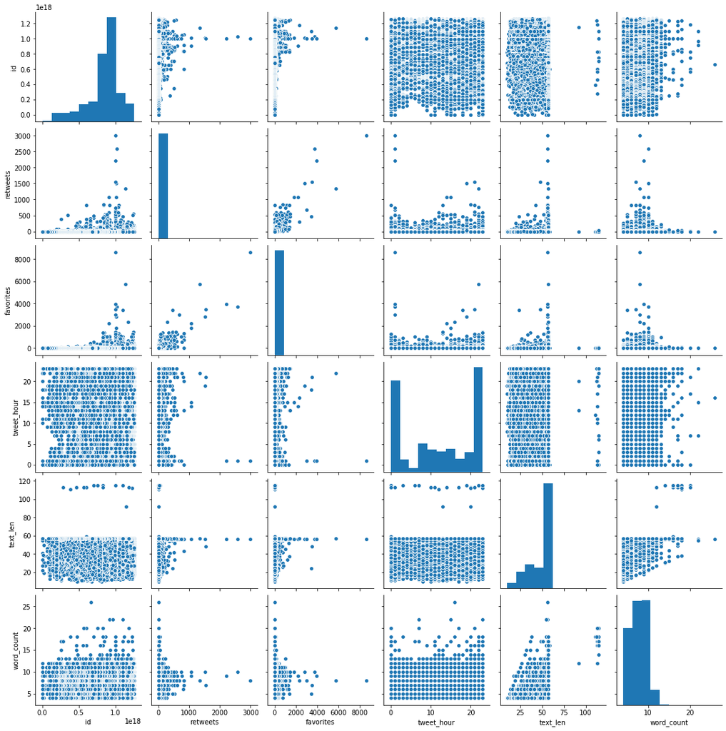

```python
sns.pairplot(df_final)
```

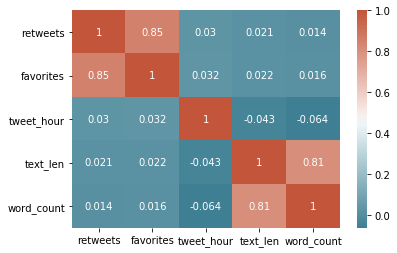

```python
# calculate correlation matrix
corr = df_final.corr()# plot the heatmap
sns.heatmap(corr, xticklabels=corr.columns,
            yticklabels=corr.columns, annot=True,
            cmap=sns.diverging_palette(220, 20, as_cmap=True))
```

Text length and word count have a positive corelations which is expected, because the more words means the more characters.

### What is the most used hashtags?

```python
#To see the most used hashtags.
hashtags = []
hashtag_pattern = re.compile(r"#[a-zA-Z]+")
hashtag_matches = list(df['text'].apply(hashtag_pattern.findall))
hashtag_dict = {}
for match in hashtag_matches:
    for singlematch in match:
        if singlematch not in hashtag_dict.keys():
            hashtag_dict[singlematch] = 1
        else:
            hashtag_dict[singlematch] = hashtag_dict[singlematch]+1
```

```python
#Making a list of the most used hashtags and their values
hashtag_ordered_list =sorted(hashtag_dict.items(), key=lambda x:x[1])
hashtag_ordered_list = hashtag_ordered_list[::-1]
#Separating the hashtags and their values into two different lists
hashtag_ordered_values = []
hashtag_ordered_keys = []
#Pick the 20 most used hashtags to plot
for item in hashtag_ordered_list[0:20]:
    hashtag_ordered_keys.append(item[0])
    hashtag_ordered_values.append(item[1])
```

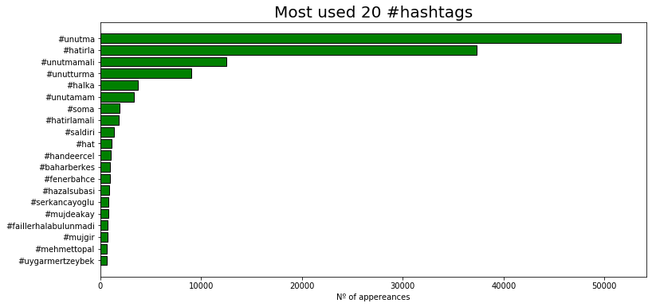

```python
#Plotting a graph with the most used hashtags
fig, ax = plt.subplots(figsize = (12,6))
y_pos = np.arange(len(hashtag_ordered_keys))
ax.barh(y_pos ,list(hashtag_ordered_values)[::-1], align='center', color = 'green', edgecolor = 'black', linewidth=1)
ax.set_yticks(y_pos)
ax.set_yticklabels(list(hashtag_ordered_keys)[::-1])
ax.set_xlabel("Nº of appereances")
ax.set_title("Most used 20 #hashtags", fontsize = 20)
plt.tight_layout(pad=3)
plt.show()
```

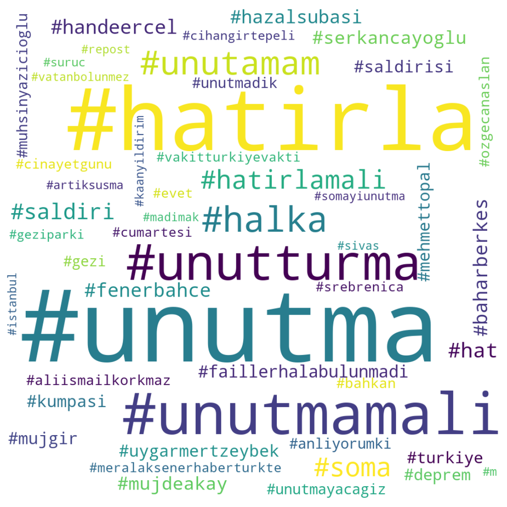

```python
#Make a wordcloud plot of the most used hashtags, for this we need a #dictionary
#where the keys are the words and the values are the number of #appearances
hashtag_ordered_dict = {}
for item in hashtag_ordered_list[0:50]:
    hashtag_ordered_dict[item[0]] = item[1]
wordcloud = WordCloud(width=1000, height=1000, random_state=21, \
                      max_font_size=200, background_color = 'white').generate_from_frequencies(hashtag_ordered_dict)
plt.figure(figsize=(30, 20))
plt.imshow(wordcloud, interpolation="bilinear")
plt.axis('off')

plt.show()
```

### Who is the most mentioned?

```python
#Now we will do the same with the mentions:
mentions = []
mention_pattern = re.compile(r"@[a-zA-Z_]+")
mention_matches = list(df['text'].apply(mention_pattern.findall))
mentions_dict = {}
for match in mention_matches:
    for singlematch in match:
        if singlematch not in mentions_dict.keys():
            mentions_dict[singlematch] = 1
        else:
            mentions_dict[singlematch] = mentions_dict[singlematch]+1
```

```python
#Create an ordered list of tuples with the most mentioned users and #the number of times they have been mentioned
mentions_ordered_list =sorted(mentions_dict.items(), key=lambda x:x[1])
mentions_ordered_list = mentions_ordered_list[::-1]
#Pick the 20 top mentioned users to plot and separate the previous #list into two list: one with the users and one with the values
mentions_ordered_values = []
mentions_ordered_keys = []
for item in mentions_ordered_list[0:20]:
    mentions_ordered_keys.append(item[0])
    mentions_ordered_values.append(item[1])
```

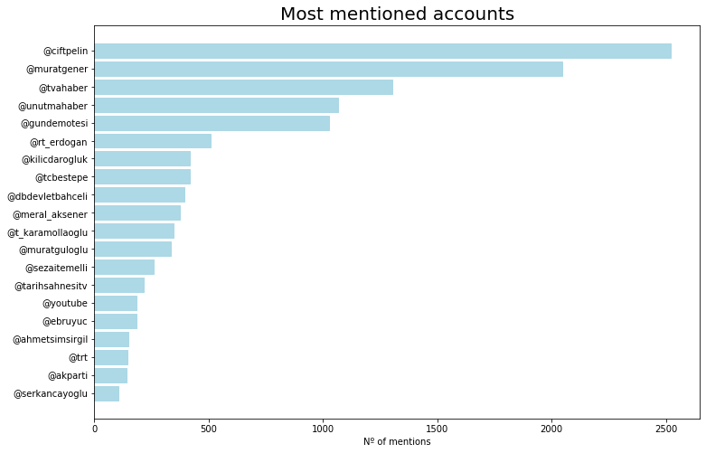

```python
fig, ax = plt.subplots(figsize = (12,8))
y_pos = np.arange(len(mentions_ordered_values))
ax.barh(y_pos ,list(mentions_ordered_values)[::-1], align='center', color = 'lightblue', edgecolor = 'lightblue', linewidth=1)
ax.set_yticks(y_pos )
ax.set_yticklabels(list(mentions_ordered_keys)[::-1])
ax.set_xlabel("Nº of mentions")
ax.set_title("Most mentioned accounts", fontsize = 20)

plt.show()
```

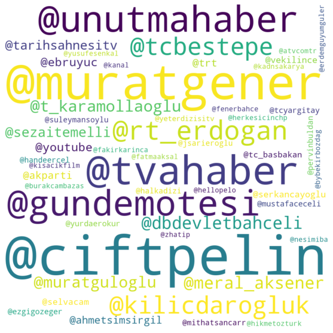

```python
#Make a wordcloud representation for the most mentioned accounts too
mentions_ordered_dict = {}
for item in mentions_ordered_list[0:50]:
    mentions_ordered_dict[item[0]] = item[1]
wordcloud = WordCloud(width=1000, height=1000, random_state=21, max_font_size=200, background_color = 'white').generate_from_frequencies(mentions_ordered_dict)
plt.figure(figsize=(15, 10))
plt.imshow(wordcloud, interpolation="bilinear")
plt.axis('off')

plt.show()
```

```python
#Lets take a look at the users who are posting these tweets:
print("There are {} different users".format(df['username'].nunique()))
```

```
There are 50256 different users
```

### Who are the users who have tweeted or retweeted the #most and see how?

```python
#Going to see who are the users who have tweeted or retweeted the #most and see how
#Likely it is that they are bots
usertweets = df.groupby('username')
#Taking the top 25 tweeting users
top_users = usertweets.count()['text'].sort_values(ascending = False)[:25]
top_users_dict = top_users.to_dict()
user_ordered_dict =sorted(top_users_dict.items(), key=lambda x:x[1])
user_ordered_dict = user_ordered_dict[::-1]
#Now, like in the previous hashtags and mention cases, going to make #two lists, one with the username and one with the value
dict_values = []
dict_keys = []
for item in user_ordered_dict[0:25]:
    dict_keys.append(item[0])
    dict_values.append(item[1])
```

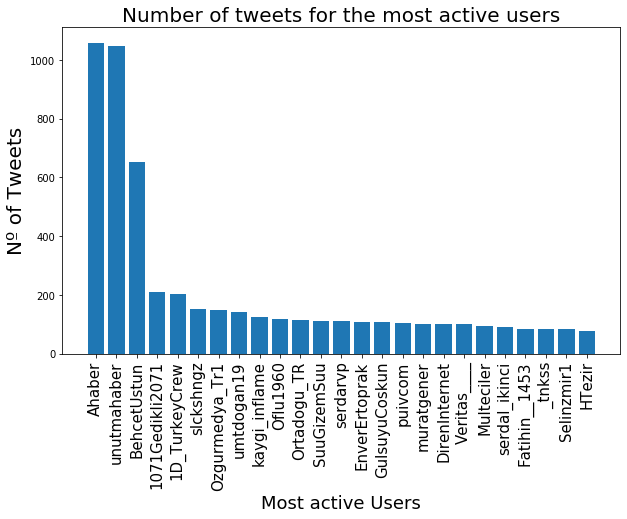

```python
#Plot these results
fig = plt.figure(figsize = (10,6))
index = np.arange(25)
plt.bar(index, dict_values, linewidth=1)
plt.xlabel('Most active Users', fontsize = 18)
plt.ylabel('Nº of Tweets', fontsize=20)
plt.xticks(index,dict_keys, fontsize=15, rotation=90)
plt.title('Number of tweets for the most active users', fontsize = 20)
plt.savefig('Tweets_of_active_users.jpg')
plt.show()
```

### Stopwords, Lemmatization, Tokenization

The words which do not change the meaning of sentence even if they are extracted are named as stopwords. While mining text, removing them provide more clear text to generate feature and model. Therefore I used nltk library to remove stopwords from tweets. [Trstop](https://github.com/ahmetax/trstop/) is also an example of removing stopwords in turkish.

```python
#from trstop import *
```

```python
#trstop.is_stop_word("yaptıkları")
```

```python
#df_final["text_processed"] = df_final["text_modified"].apply(lambda x: " ".join(x for x in x.split() if trstop.is_stop_word(x) == False))
```

```python
#df_final.tail()
```

```python
df_final.head()
```

|  | id | text_modified | hashtag | mentions | pictures | url | username | retweets | favorites | date | day | tweet_hour | text_len | word_count |
| --- | --- | --- | --- | --- | --- | --- | --- | --- | --- | --- | --- | --- | --- | --- |
| 0 | 682458513671585792 | unutma ve sadece gazetecilik yaptiklari icin ... | [#yilinsongunundeben, #unutma, #unutturma] | [@candundaradasi, @erdemgul] | [] | [] | avukatyoraz | 1 | 0 | 2015-12-31 09:09:00 | Thursday | 9 | 51 | 9 |
| 1 | 682305706121400320 | subat rizespor fenerbahce macinda futbol katli... | [#unutma, #unutturma] | [] | [] | [] | Terliksi_Kerim | 0 | 1 | 2015-12-30 23:02:00 | Wednesday | 23 | 52 | 8 |
| 2 | 681880697762660353 | unutursak kalbimiz kurusun | [#unutma, #unutturma, #hilal, #dogus] | [@hazalguvenc] | [] | [] | Fernwehhli | 0 | 0 | 2015-12-29 18:53:00 | Tuesday | 18 | 29 | 5 |
| 3 | 681673537996861444 | adaletin batsin dunya | [#soylemedenedemicem, #cocukbedenimedokunma, #... | [] | [] | [] | BuGuMm | 0 | 1 | 2015-12-29 05:10:00 | Tuesday | 5 | 24 | 5 |
| 4 | 681562788372852737 | ataturkun adini agzina alip dis guclerin oyunc... | [#unutma, #unutturma] | [] | [] | [http:// fb.me/4mccl3hie] | namluyurek | 0 | 0 | 2015-12-28 21:50:00 | Monday | 21 | 53 | 9 |

```python
#stopwords
#nltk.download('stopwords')
sw = stopwords.words('turkish')
df_final['text_modified'] = df_final['text_modified'].apply(lambda x: " ".join(x for x in x.split() if x not in sw))

#lemmi
from textblob import Word
#nltk.download('wordnet')
df_final['text_modified'] = df_final['text_modified'].apply(lambda x: " ".join([Word(word).lemmatize() for word in x.split()]))
```

```python
#wordcloud
text = " ".join(i for i in df_final.text_modified)
```

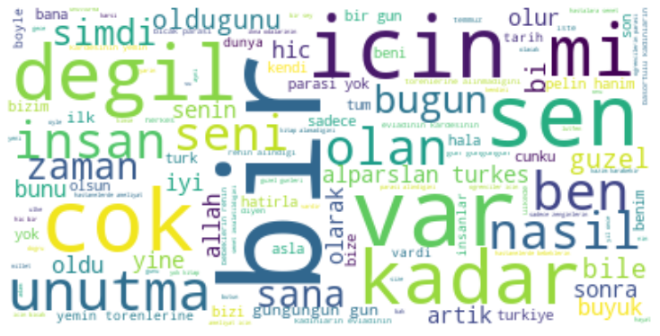

```python
wc = WordCloud(background_color = "white",
               max_words = 1000,
               contour_width = 3,
               contour_color = "firebrick")

wc.generate(text)
plt.figure(figsize=(10,10))
plt.imshow(wc, interpolation = "bilinear")
plt.axis("off")
plt.tight_layout(pad = 0)
plt.show()
```

```python
from textblob import TextBlob
```

```python
df_final["text_modified"] = df_final["text_modified"].apply(lambda x: TextBlob(x).words)
```

```python
df_final["text_modified"].head()
```

```
0    [unutma, sadece, gazetecilik, yaptiklari, icin...
1    [subat, rizespor, fenerbahce, macinda, futbol,...
2                       [unutursak, kalbimiz, kurusun]
3                            [adaletin, batsin, dunya]
4    [ataturkun, adini, agzina, alip, dis, guclerin...
Name: text_modified, dtype: object
```

```python
import gensim
import multiprocessing
from time import time
from gensim.models.phrases import Phrases, Phraser
from gensim.models import Word2Vec
from gensim.test.utils import get_tmpfile
from gensim.models import KeyedVectors
```

```python
sent = [row for row in df_final.text_modified]
phrases = Phrases(sent, min_count=3, progress_per=50000)
bigram = Phraser(phrases)
sentences = bigram[sent]
sentences[1]
```

```
['subat', 'rizespor', 'fenerbahce', 'macinda', 'futbol', 'katliami', 'var']
```

```python
w2v_model = Word2Vec(min_count=20,
                     window=2,
                     size=300,
                     sample=6e-5,
                     alpha=0.03,
                     min_alpha=0.0007,
                     negative=20,
                     workers=multiprocessing.cpu_count()-1)



start = time()

w2v_model.build_vocab(sentences, progress_per=50000)

print('Time to build vocab: {} mins'.format(round((time() - start) / 60, 2)))
```

```
Time to build vocab: 0.04 mins
```

```python
start = time()

w2v_model.train(sentences, total_examples=w2v_model.corpus_count, epochs=30, report_delay=1)

print('Time to train the model: {} mins'.format(round((time() - start) / 60, 2)))

w2v_model.init_sims(replace=True)
```

```
Time to train the model: 0.88 mins
```

```python
w2v_model.save("word2vec.model")
```

```python
df_export = df_final.copy()
df_export['old_text'] = df_export.text_modified
df_export.old_text = df_export.old_text.str.join(' ')
df_export.text_modified = df_export.text_modified.apply(lambda x: ' '.join(bigram[x]))
```

```python
df_export[['text_modified']].to_csv('cleaned_dataset.csv', index=False)
```

### Kmeans Clustering in Text Mining

```python
word_vectors = Word2Vec.load("word2vec.model").wv
```

```python
from sklearn.cluster import KMeans
model = KMeans(n_clusters=2, max_iter=1000, random_state=True, n_init=50).fit(X=word_vectors.vectors)
```

```python
word_vectors.similar_by_vector(model.cluster_centers_[0], topn=10, restrict_vocab=None)
```

```
[('goruyorum', 0.9663790464401245),
 ('gercekten_sevenin', 0.9616042375564575),
 ('hatirlatma', 0.9610273241996765),
 ('dunyanin_guzel', 0.9604052901268005),
 ('necip_fazil', 0.9603256583213806),
 ('anlam', 0.9591178297996521),
 ('anlik', 0.9571801424026489),
 ('guzel_seyler', 0.9528288245201111),
 ('etrafinda', 0.952536940574646),
 ('etmeyin', 0.9510136842727661)]
```

```python
positive_cluster_center = model.cluster_centers_[0]
negative_cluster_center = model.cluster_centers_[1]
```

```python
words = pd.DataFrame(word_vectors.vocab.keys())
words.columns = ['words']
words['vectors'] = words.words.apply(lambda x: word_vectors.wv[f'{x}'])
words['cluster'] = words.vectors.apply(lambda x: model.predict([np.array(x)]))
words.cluster = words.cluster.apply(lambda x: x[0])
```

```python
words['cluster_value'] = [1 if i==0 else -1 for i in words.cluster]
words['closeness_score'] = words.apply(lambda x: 1/(model.transform([x.vectors]).min()), axis=1)
words['sentiment_coeff'] = words.closeness_score * words.cluster_value
```

```python
words.head(10)
```

|  | words | vectors | cluster | cluster_value | closeness_score | sentiment_coeff |
| --- | --- | --- | --- | --- | --- | --- |
| 0 | unutma | [-0.11568051, -0.18016987, -0.046771288, 0.016... | 1 | -1 | 1.179658 | -1.179658 |
| 1 | sadece | [0.0025849277, -0.011357391, 0.026733866, -0.0... | 0 | 1 | 1.646079 | 1.646079 |
| 2 | yaptiklari | [-0.07817882, -0.123896316, 0.007657741, -0.07... | 0 | 1 | 1.604236 | 1.604236 |
| 3 | icin | [-0.066558875, -0.015619468, 0.005226524, -0.0... | 1 | -1 | 1.190310 | -1.190310 |
| 4 | subat | [-0.05263743, -0.04828841, -0.111625396, -0.06... | 1 | -1 | 1.386471 | -1.386471 |
| 5 | fenerbahce | [0.04171719, -0.033753805, -0.14450833, -0.052... | 1 | -1 | 1.426786 | -1.426786 |
| 6 | macinda | [-0.008310135, -0.070543624, -0.08717942, -0.0... | 1 | -1 | 1.603436 | -1.603436 |
| 7 | futbol | [0.007084238, -0.017776333, -0.076847315, -0.0... | 1 | -1 | 1.582074 | -1.582074 |
| 8 | katliami | [-0.007939969, -0.04027906, -0.06727601, -0.05... | 1 | -1 | 1.496073 | -1.496073 |
| 9 | var | [0.029503776, 0.017856464, 0.027637886, -0.089... | 0 | 1 | 1.439111 | 1.439111 |

```python
words[['words', 'sentiment_coeff']].to_csv('sentiment_dictionary.csv', index=False)
```

```python
final_file = pd.read_csv('cleaned_dataset.csv')
```

```python
sentiment_map = pd.read_csv('sentiment_dictionary.csv')
sentiment_dict = dict(zip(sentiment_map.words.values, sentiment_map.sentiment_coeff.values))
```

```python
file_weighting = final_file.copy().dropna().reset_index()
```

```python
file_weighting.head()
```

|  | index | text_modified |
| --- | --- | --- |
| 0 | 0 | unutma sadece gazetecilik yaptiklari icin gund... |
| 1 | 1 | subat rizespor fenerbahce macinda futbol katli... |
| 2 | 2 | unutursak_kalbimiz kurusun |
| 3 | 3 | adaletin batsin dunya |
| 4 | 4 | ataturkun adini_agzina alip dis_guclerin oyunc... |

[output not shown]

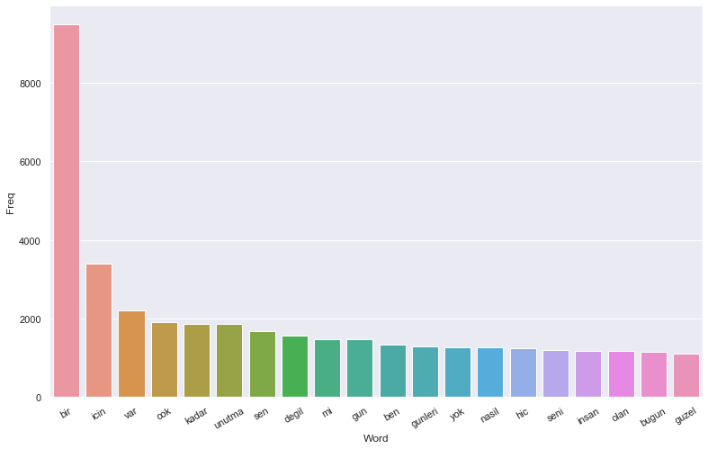

```python
#Most frequently occuring words
def get_top_n_words(corpus, n=None):
    vec = CountVectorizer().fit(corpus)
    bag_of_words = vec.transform(corpus)
    sum_words = bag_of_words.sum(axis=0)
    words_freq = [(word, sum_words[0, idx]) for word, idx in
                   vec.vocabulary_.items()]
    words_freq =sorted(words_freq, key = lambda x: x[1],
                       reverse=True)
    return words_freq[:n]
#Convert most freq words to dataframe for plotting bar plot
top_words = get_top_n_words(file_weighting.text_modified, n=20)
top_df = pd.DataFrame(top_words)
top_df.columns=["Word", "Freq"]
#Barplot of most freq words
import seaborn as sns
sns.set(rc={'figure.figsize':(13,8)})
g = sns.barplot(x="Word", y="Freq", data=top_df)
g.set_xticklabels(g.get_xticklabels(), rotation=30)
```

It is understood that stopwords were not removed from dataset because words like "bir, icin, cok, sen, ben" can be counted as stopwords for turkish. Let's look at most frequently occuring bi-grams:

```
                                      Bi-gram  Freq
0                                     bir gun   415
1      evladinin_kardesinin yemin_torenlerine   396
2   basortulu_kadinlarin evladinin_kardesinin   394
3              yemin_torenlerine alinmadigini   381
4            hastanelerde_ameliyat icin_bicak   359
5                icin_bicak parasi_alindigini   356
6      hastanelerde_bebeklerin rehin_alindigi   355
7               ogrencilerin_parasi yok_kitap   306
8                       yok_kitap alamadigini   295
9                                     hic bir   288
10  basortulu_ogrenciler icin_universitelerde   255
11       icin_universitelerde ikna_odalarinin   255
12                ikna_odalarinin kuruldugunu   246
13                 devlete_imf kapilarinda_el   241
14               kapilarinda_el actirildigini   232
15  ucaklara_sadece zenginlerin_binebildigini   230
16            hastalara_senet imzalatildigini   223
17               parasi_yok insanlarin_tedavi   221
18          evlere_tankerlerle su_tasindigini   203
19         basi_ortulu ogrencilerin_kazandigi   196
```

[output not shown]

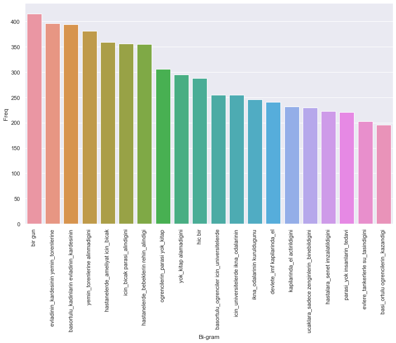

```python
#Most frequently occuring Bi-grams
def get_top_n2_words(corpus, n=None):
    vec1 = CountVectorizer(ngram_range=(2,2),
            max_features=2000).fit(corpus)
    bag_of_words = vec1.transform(corpus)
    sum_words = bag_of_words.sum(axis=0)
    words_freq = [(word, sum_words[0, idx]) for word, idx in
                  vec1.vocabulary_.items()]
    words_freq =sorted(words_freq, key = lambda x: x[1],
                reverse=True)
    return words_freq[:n]
top2_words = get_top_n2_words(file_weighting.text_modified, n=20)
top2_df = pd.DataFrame(top2_words)
top2_df.columns=["Bi-gram", "Freq"]
print(top2_df)
#Barplot of most freq Bi-grams
import seaborn as sns
sns.set(rc={'figure.figsize':(13,8)})
h=sns.barplot(x="Bi-gram", y="Freq", data=top2_df)
h.set_xticklabels(h.get_xticklabels(), rotation=90)
```

```
                                             Tri-gram  Freq
0   basortulu_kadinlarin evladinin_kardesinin yemi...   394
1   evladinin_kardesinin yemin_torenlerine alinmad...   380
2   hastanelerde_ameliyat icin_bicak parasi_alindi...   356
3           ogrencilerin_parasi yok_kitap alamadigini   288
4   basortulu_ogrenciler icin_universitelerde ikna...   255
5    icin_universitelerde ikna_odalarinin kuruldugunu   246
6            devlete_imf kapilarinda_el actirildigini   232
7            parasi_yok insanlarin_tedavi olamadigini   189
8   basi_ortulu ogrencilerin_kazandigi okula_girem...   185
9   bankalari_hortumlayarak milletin_malinin calin...   160
10       oz_vataninda inancini_ozgurce yasayamadigini   147
11            millete_vatan vatana_devlet devlete_bey   142
12                    vatana_devlet devlete_bey gerek   142
13                  karneyle_gaz ekmek_yag alindigini   141
14             paran_kadar oku_yaz dusuncesine_mahkum   139
15     karda_kista kadinlarin_doguma goturulemedigini   133
16         enflasyonun_yuzde lara_lere lere_ciktigini   126
17              oku_yaz dusuncesine_mahkum edildigini   125
18           krizinde_dukkanlarin tek_tek kapandigini   114
19                                      hic bir zaman    95
```

[output not shown]

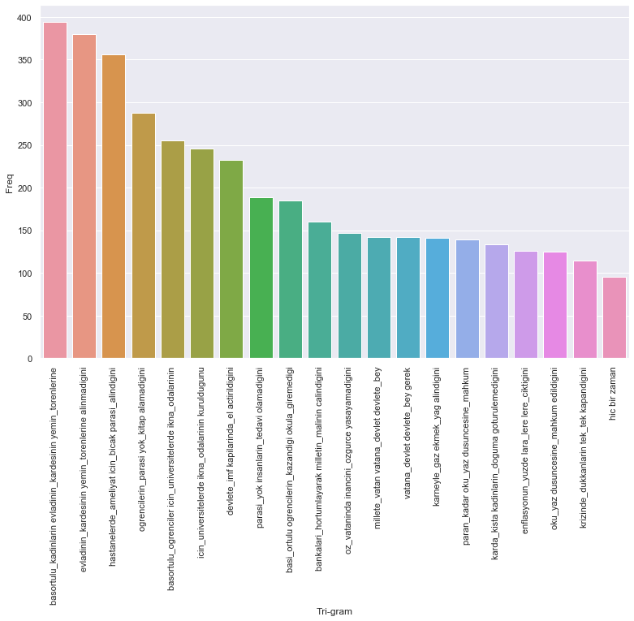

```python
#Most frequently occuring Tri-grams
def get_top_n3_words(corpus, n=None):
    vec1 = CountVectorizer(ngram_range=(3,3),
           max_features=2000).fit(corpus)
    bag_of_words = vec1.transform(corpus)
    sum_words = bag_of_words.sum(axis=0)
    words_freq = [(word, sum_words[0, idx]) for word, idx in
                  vec1.vocabulary_.items()]
    words_freq =sorted(words_freq, key = lambda x: x[1],
                reverse=True)
    return words_freq[:n]
top3_words = get_top_n3_words(file_weighting.text_modified, n=20)
top3_df = pd.DataFrame(top3_words)
top3_df.columns=["Tri-gram", "Freq"]
print(top3_df)
#Barplot of most freq Tri-grams
import seaborn as sns
sns.set(rc={'figure.figsize':(13,8)})
j=sns.barplot(x="Tri-gram", y="Freq", data=top3_df)
j.set_xticklabels(j.get_xticklabels(), rotation=90)
```

```python
tfidf = TfidfVectorizer(tokenizer=lambda y: y.split(), norm=None)
tfidf.fit(file_weighting.text_modified)
features = pd.Series(tfidf.get_feature_names())
transformed = tfidf.transform(file_weighting.text_modified)
```

```python
def create_tfidf_dictionary(x, transformed_file, features):
    '''
    create dictionary for each input sentence x, where each word has assigned its tfidf score

    inspired  by function from this wonderful article:
    https://medium.com/analytics-vidhya/automated-keyword-extraction-from-articles-using-nlp-bfd864f41b34

    x - row of dataframe, containing sentences, and their indexes,
    transformed_file - all sentences transformed with TfidfVectorizer
    features - names of all words in corpus used in TfidfVectorizer

    '''
    vector_coo = transformed_file[x.name].tocoo()
    vector_coo.col = features.iloc[vector_coo.col].values
    dict_from_coo = dict(zip(vector_coo.col, vector_coo.data))
    return dict_from_coo

def replace_tfidf_words(x, transformed_file, features):
    '''
    replacing each word with it's calculated tfidf dictionary with scores of each word
    x - row of dataframe, containing sentences, and their indexes,
    transformed_file - all sentences transformed with TfidfVectorizer
    features - names of all words in corpus used in TfidfVectorizer
    '''
    dictionary = create_tfidf_dictionary(x, transformed_file, features)
    return list(map(lambda y:dictionary[f'{y}'], x.text_modified.split()))
```

```python
%%time
replaced_tfidf_scores = file_weighting.apply(lambda x: replace_tfidf_words(x, transformed, features), axis=1)
#this step takes around 3-4 minutes minutes to calculate
```

```
CPU times: user 23.2 s, sys: 141 ms, total: 23.4 s
Wall time: 1min 31s
```

```python
def replace_sentiment_words(word, sentiment_dict):
    '''
    replacing each word with its associated sentiment score from sentiment dict
    '''
    try:
        out = sentiment_dict[word]
    except KeyError:
        out = 0
    return out
```

```python
replaced_closeness_scores = file_weighting.text_modified.apply(lambda x:
                                                               list(map(lambda y:
                                                                        replace_sentiment_words(y, sentiment_dict), x.split()
                                                                       )
                                                                   )
                                                              )
```

```python
replacement_df = pd.DataFrame(data=[replaced_closeness_scores, replaced_tfidf_scores, file_weighting.text_modified]).T
replacement_df.columns = ['sentiment_coeff', 'tfidf_scores', 'tweet']
replacement_df['sentiment_rate'] = replacement_df.apply(lambda x: np.array(x.loc['sentiment_coeff']) @ np.array(x.loc['tfidf_scores']), axis=1)
replacement_df['prediction'] = (replacement_df.sentiment_rate>0).astype('int8')
#replacement_df['sentiment'] = [1 if i==1 else 0 for i in replacement_df.sentiment]
```

```python
replacement_df["prediction"].value_counts()/len(replacement_df)
```

```
1    0.511277
0    0.488723
Name: prediction, dtype: float64
```

```python
replacement_df[replacement_df["prediction"] == 0].head()
```

|  | sentiment_coeff | tfidf_scores | tweet | sentiment_rate | prediction |
| --- | --- | --- | --- | --- | --- |
| 1 | [-1.3864711114840536, 0, -1.4267858141238177, ... | [7.535631481610388, 11.216142686053809, 7.5107... | subat rizespor fenerbahce macinda futbol katli... | -54.463331 | 0 |
| 2 | [-1.0974927644617387, -1.017985017262288] | [7.750406783254082, 7.2778023723082885] | unutursak_kalbimiz kurusun | -15.914709 | 0 |
| 3 | [-1.4485897765768396, 0, 1.5917599659841966] | [8.363511256140491, 10.705317062287817, 6.1409... | adaletin batsin dunya | -2.340349 | 0 |
| 4 | [-1.373883074516394, 0, -1.4967911742351203, 0... | [7.932728340048036, 10.522995505493864, 7.5785... | ataturkun adini_agzina alip dis_guclerin oyunc... | -40.365534 | 0 |
| 6 | [0, 0, -1.4938057133853633] | [10.235313433042082, 11.621607794161973, 6.310... | faciasi zanlilarivar ulkede | -9.427211 | 0 |

```python
replacement_df[replacement_df["prediction"] == 1].head()
```

|  | sentiment_coeff | tfidf_scores | tweet | sentiment_rate | prediction |
| --- | --- | --- | --- | --- | --- |
| 0 | [-1.179657588295108, 1.6460787057160278, 0, 1.... | [4.856568817381431, 5.593329273931274, 9.82984... | unutma sadece gazetecilik yaptiklari icin gund... | 11.728734 | 1 |
| 5 | [0, 1.3743225392136016, 1.3927802486628118, 0,... | [9.67569764510666, 6.057087386839279, 6.623861... | tam_sene once bir katliym yasanms ananin yureg... | 51.466894 | 1 |
| 11 | [1.6052850156859273, -1.4830772738303046, 1.67... | [6.134738321069345, 7.670364075580546, 8.65119... | bizi zamaninda satan ersun yanal geri gelmemeli | 23.936137 | 1 |
| 13 | [0, 1.5129966990602213] | [10.705317062287817, 8.731236036265809] | insanligin_oldugu yerdir | 13.210331 | 1 |
| 16 | [1.387194268879102, 1.3927802486628118, 0] | [5.362982810323007, 3.311930898174246, 11.6216... | guzel bir tevafuk | 12.052291 | 1 |

It seems a balanced prediction of datasets according to predicted labels.

## Results - *What I learned for my capstone project?*

This project is done with simple and well-known text processing techniques, even if it is known these are not well worked in Turkish texts. It can be counted learnings from this project below:

- Preprocessing is still the most important part of modeling. Libraries developed for English do not fit properly to Turkish text as shown above. Therefore, libraries developed for Turkish sentiment should be used.
- Numbers should be removed before modeling. However, numbers corresponding to date could be important for topic classification in tweet mining. So, these numbers should be converted to text before modeling. *They were removed in this project.*
- People have not been pay attention to grammar rules while posting a tweet. To get a more clear dataset, the conversion of social text to a proper one should be done. For example, "olmaaaaaz" should be converted to "olmaz".
- Spelling errors should be fixed before modeling. For instance, "slm" should be converted to "selam".
- There are still some text processing problems such as redundant space. This causes calculating wrongly word count or text length features.
- The some part of dataset may be labeled manually, then, supervised learning applied on datasets. This way may be time consuming, however, it would be help to develop more accurate model.

## References

[1] https://github.com/Jefferson-Henrique/GetOldTweets-python

- Simplifying Sentiment Analysis using VADER in Python (on Social Media Text) https://medium.com/analytics-vidhya/simplifying-social-media-sentiment-analysis-using-vader-in-python-f9e6ec6fc52f
- Text Preprocessing in Python: Steps, Tools, and Examples https://medium.com/@datamonsters/text-preprocessing-in-python-steps-tools-and-examples-bf025f872908
- Extracting Twitter Data, Pre-Processing and Sentiment Analysis using Python 3.0 https://towardsdatascience.com/extracting-twitter-data-pre-processing-and-sentiment-analysis-using-python-3-0-7192bd8b47cf
- Classifying Tweets for Sentiment Analysis: Natural Language Processing in Python for Beginners https://medium.com/vickdata/detecting-hate-speech-in-tweets-natural-language-processing-in-python-for-beginners-4e591952223
- Aspect-Based Opinion Mining (NLP with Python) https://medium.com/@pmin91/aspect-based-opinion-mining-nlp-with-python-a53eb4752800
- Sentiment analysis : Machine-Learning approach https://medium.com/datadriveninvestor/sentiment-analysis-machine-learning-approach-83e4ba38b57
- Effectively Pre-processing the Text Data Part 1: Text Cleaning https://towardsdatascience.com/effectively-pre-processing-the-text-data-part-1-text-cleaning-9ecae119cb3e
- Unsupervised Sentiment Analysis https://towardsdatascience.com/unsupervised-sentiment-analysis-a38bf1906483
- Building Blocks: Text Pre-Processing https://towardsdatascience.com/building-blocks-text-pre-processing-641cae8ba3bf
- Sentiment Analysis of Tweets using Multinomial Naive Bayes https://towardsdatascience.com/sentiment-analysis-of-tweets-using-multinomial-naive-bayes-1009ed24276b
- A Complete Exploratory Data Analysis and Visualization for Text Data https://towardsdatascience.com/a-complete-exploratory-data-analysis-and-visualization-for-text-data-29fb1b96fb6a
- Tweet analytics using NLP https://towardsdatascience.com/tweet-analytics-using-nlp-f83b9f7f7349
- Creating The Twitter Sentiment Analysis Program in Python with Naive Bayes Classification https://towardsdatascience.com/creating-the-twitter-sentiment-analysis-program-in-python-with-naive-bayes-classification-672e5589a7ed
- Sentiment analysis context https://www.dezyre.com/student-project/toly-novik-text-mining-and-clustering-of-tweets-based-on-context/2
- Exploring Twitter API and Data Using Tweepy, Pandas and Matplotlib. — Part 1 https://medium.com/@adamichelllle/exploring-twitter-api-and-data-using-tweepy-pandas-and-matplotlib-part-1-2ac07fcc4717
- The Next Level of Data Visualization in Python https://towardsdatascience.com/the-next-level-of-data-visualization-in-python-dd6e99039d5e
- https://www.earthdatascience.org/courses/use-data-open-source-python/intro-to-apis/calculate-tweet-word-frequencies-in-python/
- Visualisation of Information from Raw Twitter Data — Part 1 https://towardsdatascience.com/visualization-of-information-from-raw-twitter-data-part-1-99181ad19c